# Results Exploration

2025-04-11

Return to Model README: [README](https://github.com/benjhodgson/metapop_capacity_matrix/blob/main/README.md)

# 1 Metapopulation Persistence

## 1.1 Equal Colonisation and Extinction

### 1.1.1 Sparing and Sharing with low to very high levels of dispersal

Under high or medium levels of habitat aggregation, a clear sparing response is seen for species with low to very high levels of dispersal (0.1 - 10 km mean dispersal at relative yield = 1). I.e. the greater the proportion of habitat, the greater the difference between metapopulation capacity and the persistence threshold.

For example, here are the results for the difference between metapopulation capacity and several species persistence threshold responses (delta) for species with medium levels of dispersal, with a medium level of aggregation, and with responses that increase dispersal distance by a maximum of 500%:

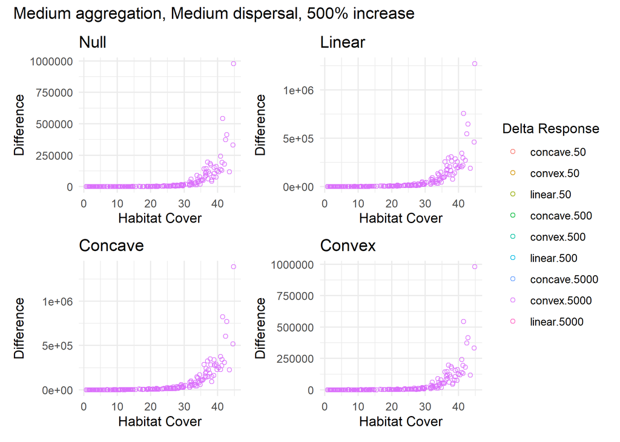

The plots are very similar and delta makes very little difference. We can compare them more easily when overlapped (difference from linear delta 50):

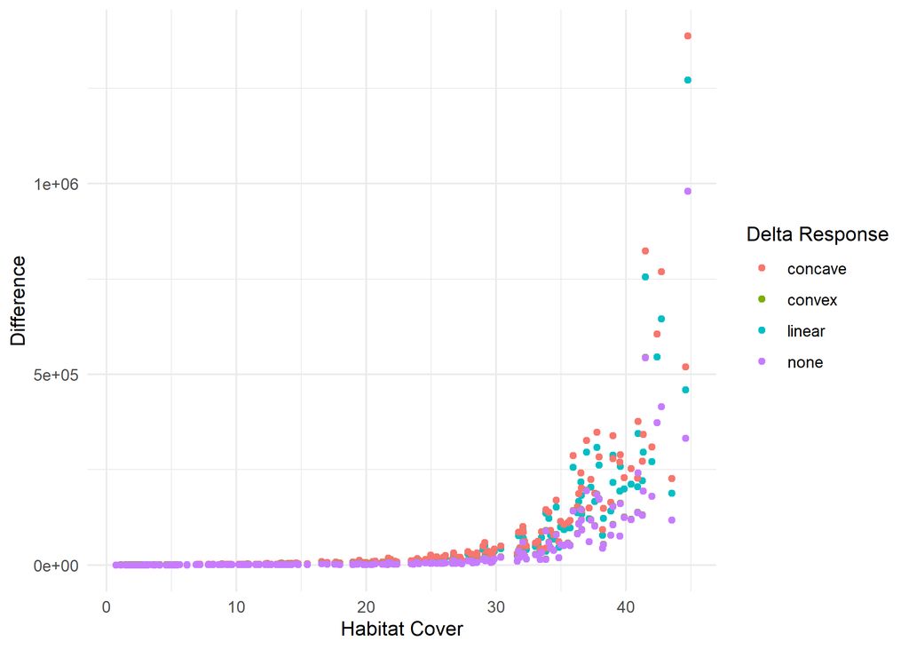

Now you can see that linear and concave have greater differences at high and medium levels of habitat cover. If we plot the species dispersal distance at each level of habitat cover we can see that concave and linear responses increase their dispersal ability quickly with a small decrease in habitat cover. Convex responses, however, only increase their mean dispersal distance after a substantial amount of habitat has been removed. At low levels of habitat cover, the lack of suitable habitat is more likely limiting species persistence, meaning that all responses have a low difference.

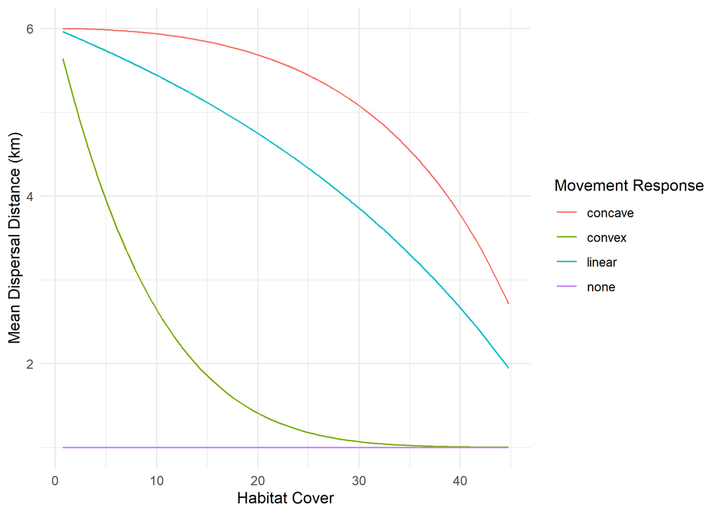

For reference, this is the mean inter-patch distance for the landscapes (medium aggregation).

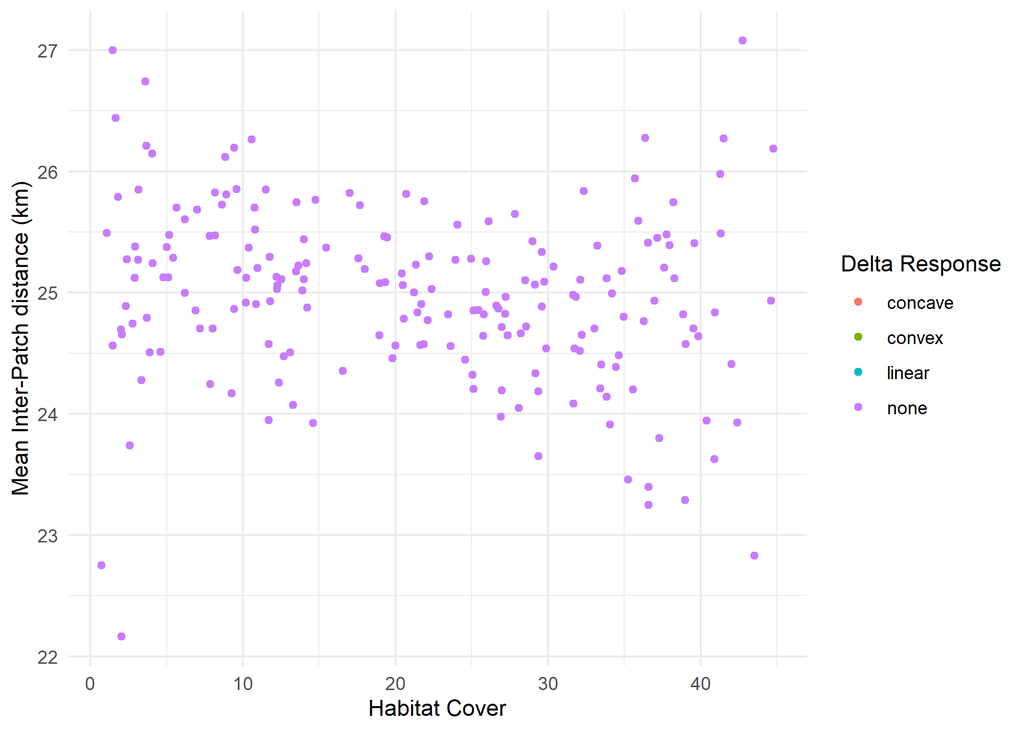

The magnitude of the increase in dispersal also affects the shape of the difference response to habitat cover, with higher increases in dispersal ability with yield leading to an increased difference at high and medium levels of habitat cover.

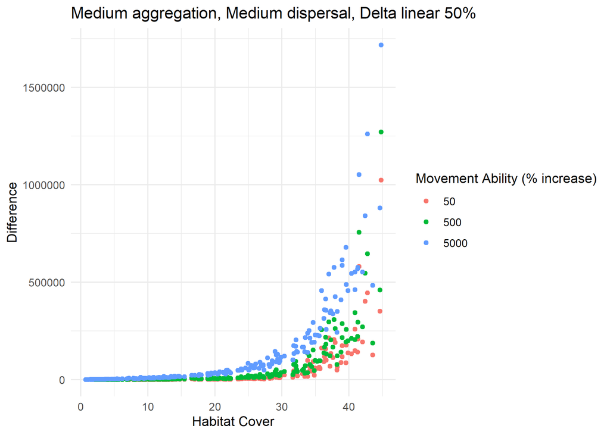

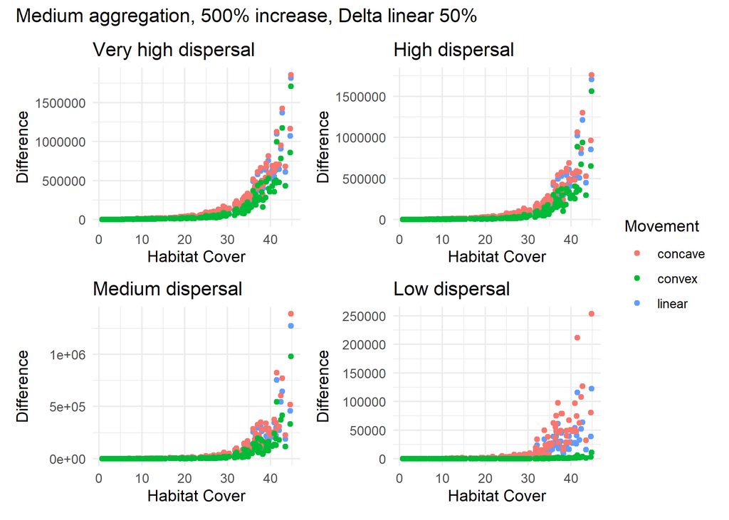

When we compare habitat aggregation levels, we can see that metapopulation capacity rises much quicker in low aggregation landscapes than in medium or high aggregation landscapes. This may be due to smaller distances between patches in low aggregation landscapes, meaning total habitat area can have a greater impact on metapopulation capacity. (Difference from linear delta 50% for 500% responses):

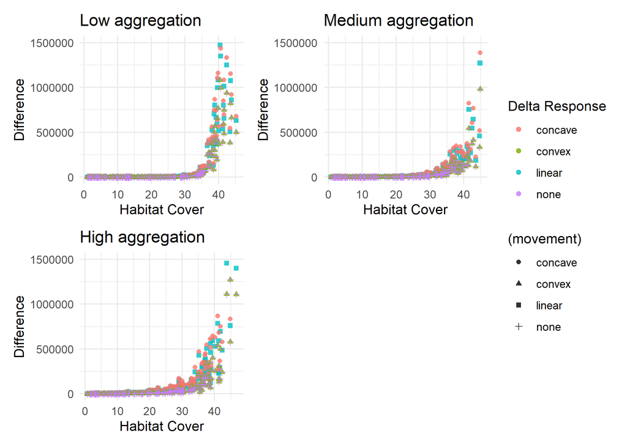

A unique result can be seen when dispersal ability increases massively (5000%) in a convex way in medium and high aggregation landscapes.This is most evident in high aggregation landscapes, is less evident in medium aggregation landscapes, and is not clearly visible in low aggregation landscapes.

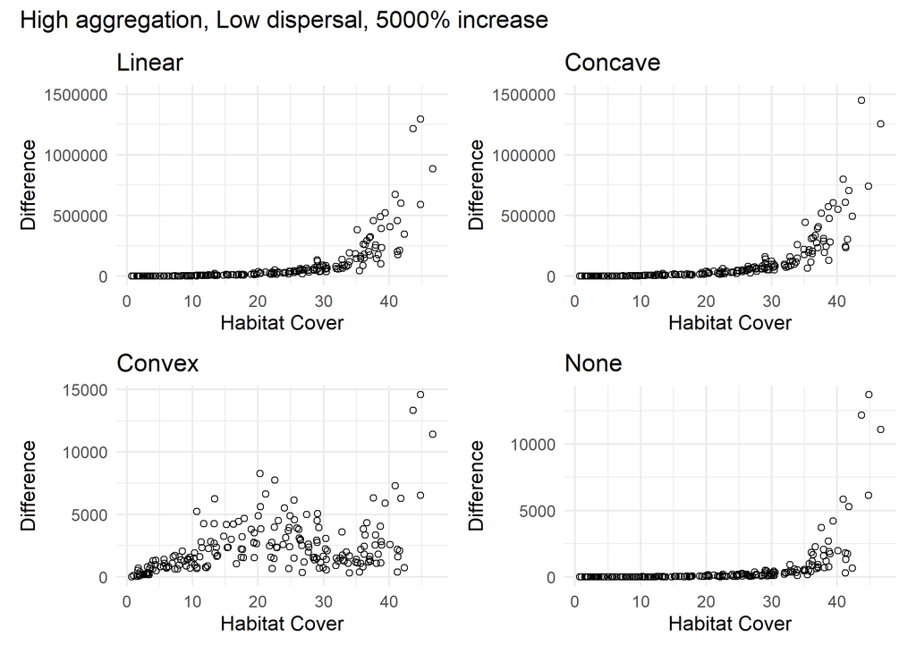

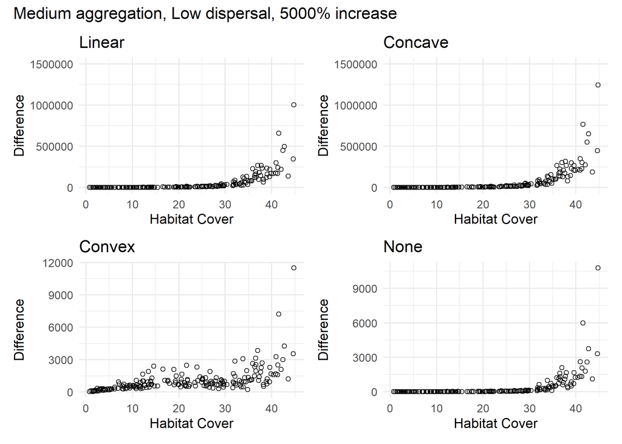

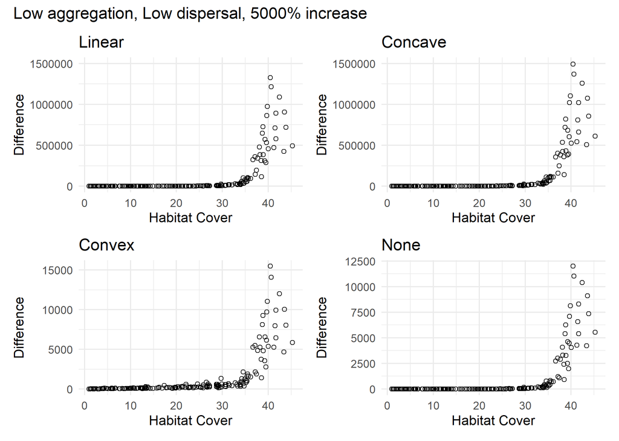

For reference here are the dispersal increase curves for 5000%:

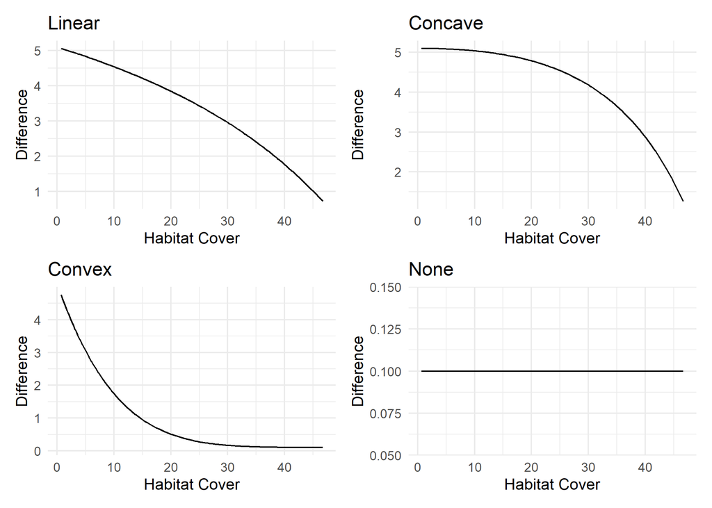

Here, linear and concave follow a similar pattern as described previously. The convex response however has a much reduced difference at medium to high levels of habitat cover (note the y axis). If, however, you look closely at the convex response, you can see a multimodal response. Difference increases with habitat cover to around 20% habitat cover. It then declines before increasing again at around 35%. This pattern is due to linear and concave responses having sufficient dispersal at intermediate to high levels of cover for the difference to increase continuously in line with habitat cover. For the convex response however, difference first increases with habitat cover (dispersal is sufficient here), but then declines as dispersal declines quickly. It is only when habitat cover continues to increase that the difference begins to increase again, although this increase is small in comparison to the linear and concave responses due to a lack of dispersal ability. For low aggregation landscapes, the smaller distance between habitat patches likely means that increased dispersal has less of an impact on metapopulation capacity. The difference between metapopulation capacity and the persistence threshold is much smaller at these intermediate levels of habitat cover for low aggregation landscapes compared to high aggregation landscapes. High aggregation landscapes likely benefit from larger patch sizes but are more limited by insufficient dispersal. When dispersal increases, metapopulation capacity can peak higher than in low aggregation landscapes.

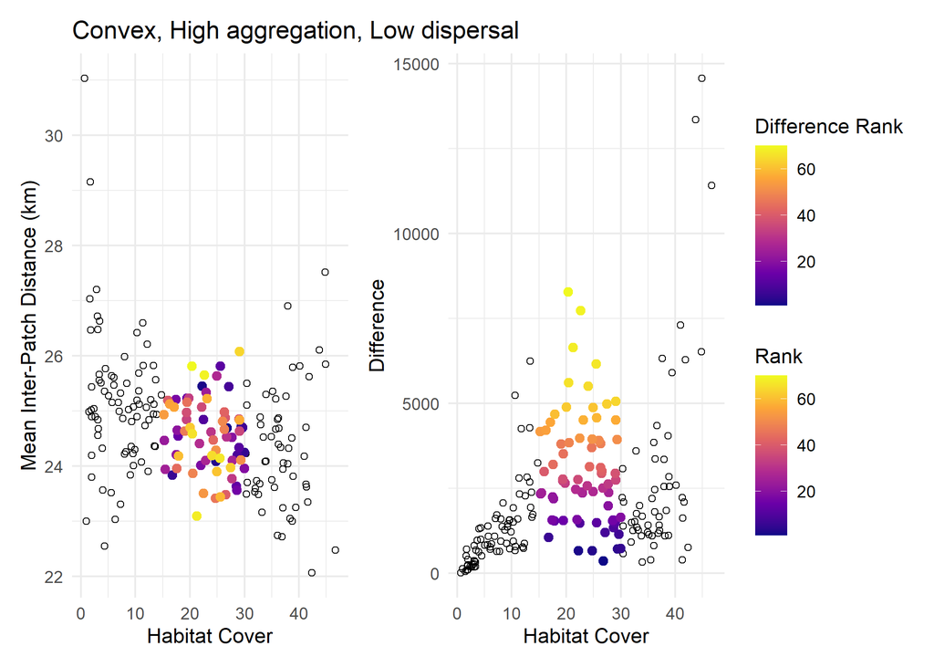

The large variation is not obviously due to a difference in mean inter-patch distance, edge density, number of patches or the mean size of patches. For landscapes with a landscape cover of 20-22%, the landscapes with the lowest and highest difference are shown:

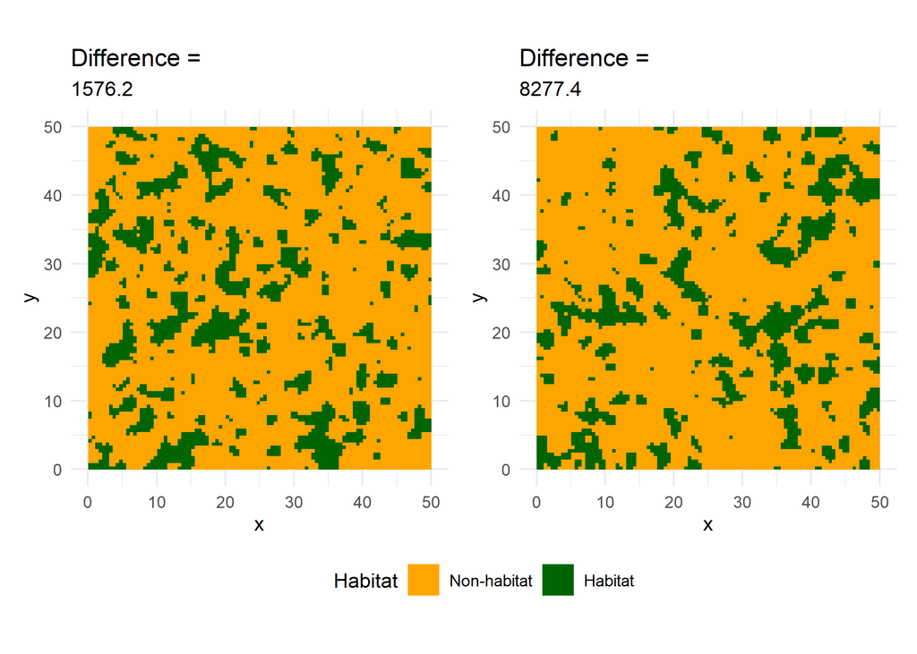

### 1.1.2 Sparing and Sharing with very low levels of dispersal

When the mean dispersal of species is highly limited (10 m at relative yield = 1), a clear sparing response is no longer seen. For example, when habitat aggregation is low and there is a very large increase in dispersal ability, the difference between metapopulation capacity and the persistence threshold is greatest before the maximum amount of habitat for linear, concave and convex responses. For the null response (no increase in mean dispersal distance), metapopulation capacity is so low that even if the colonisation constant increased dramatically, persistence would not be possible. For the linear and concave responses, the difference peaks just above 40% habitat cover and declines rapidly approaching 45% habitat cover. The difference remains quite large here, although there remains a large level of variation. For the convex response, the difference peaks at around 5-10% habitat cover. Again there is a large variation, however, the magnitude of the difference for the convex response is very low, and differences between the possible delta responses can be seen.

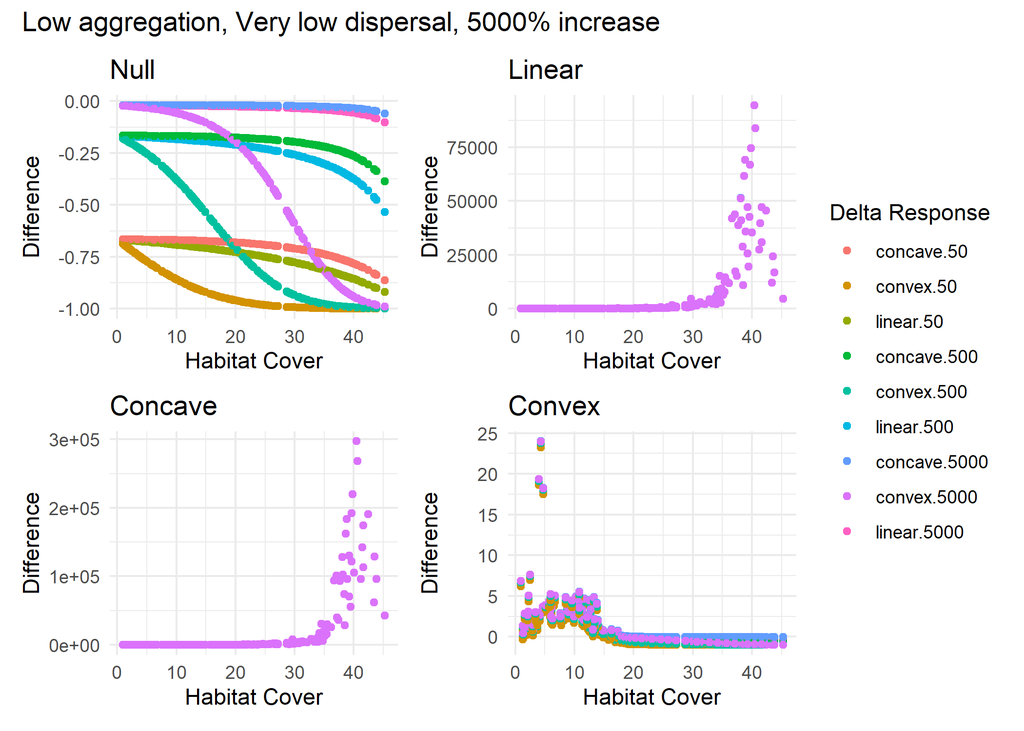

[figure not shown]

At high levels of habitat cover and low levels of habitat aggregation, it can be very difficult to explain the exact underlying reason for variation, even though the variation has to be a product of the habitat structure. For example these two landscapes have habitat covers between 40 and 42% but differ dramatically in their metapopulation capacity.

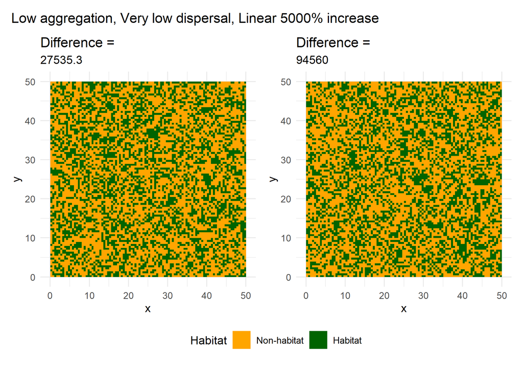

For very poor disperses in low aggregated landscapes when the increase in dispersal ability is not as extreme (only 500% increase), only the concave dispersal response can really allow for some species persistence. For the concave response, the peak is slightly lower (~25-40% habitat cover), the maximum difference is very small, and the importance of how the colonisation constant, and in turn the persistence threshold changes in response to yield becomes much more visible. The linear and convex responses are very similar to the null response. By the time dispersal ability increases, habitat cover is too low, and the dispersal increases is too little to greatly increase the difference.

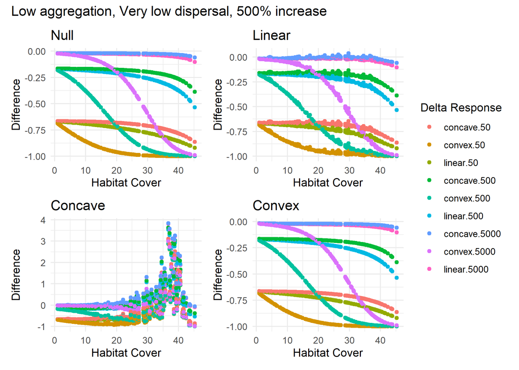

When the dispersal increase is less still, all responses are very similar to the null response:

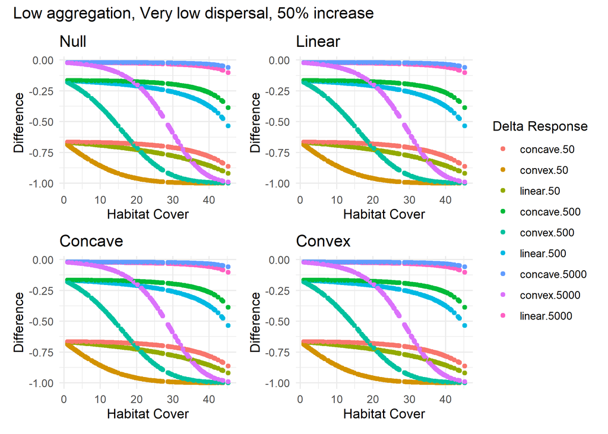

A similar pattern can be seen across levels of habitat aggregation, however, there is a trend of increasing difference variation as aggregation increases. The peaks in difference also widen. For example, in low aggregation landscapes, the difference peaks between ~35% to ~40% habitat cover for the concave response. This peak widens to ~20% to ~40% in high aggregation landscapes.

It can also be seen that with increased aggregation, more landscapes fall above the persistence threshold for the linear response (500%), although this is only the case when the colonisation constant also increases a great amount (500% +).

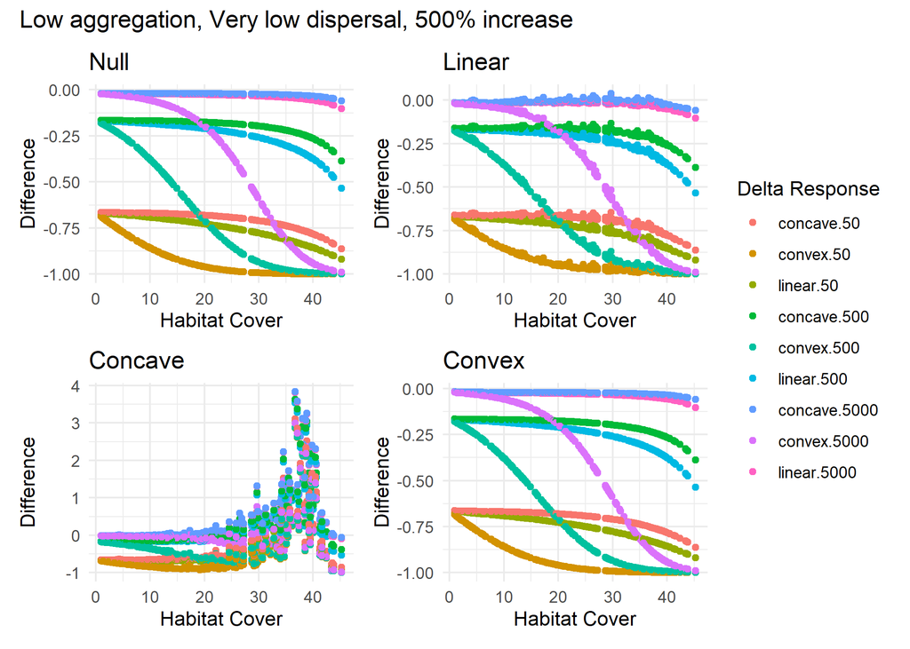

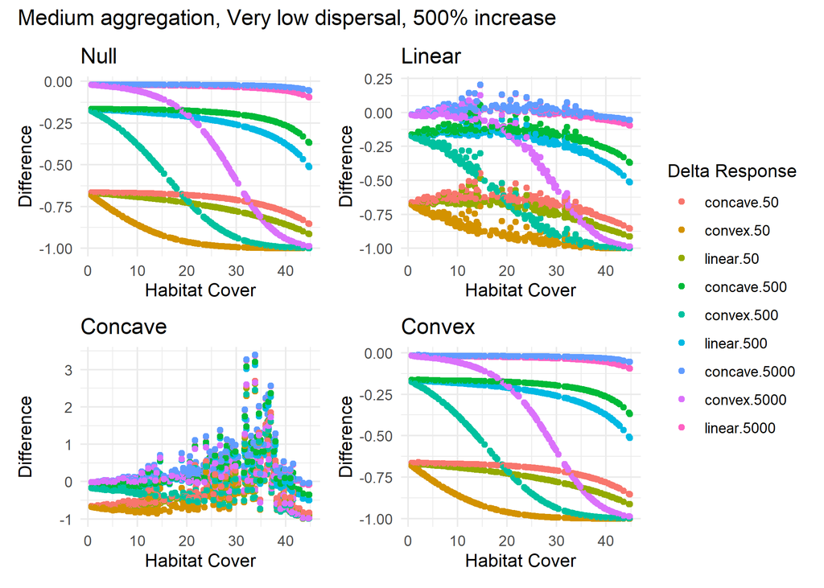

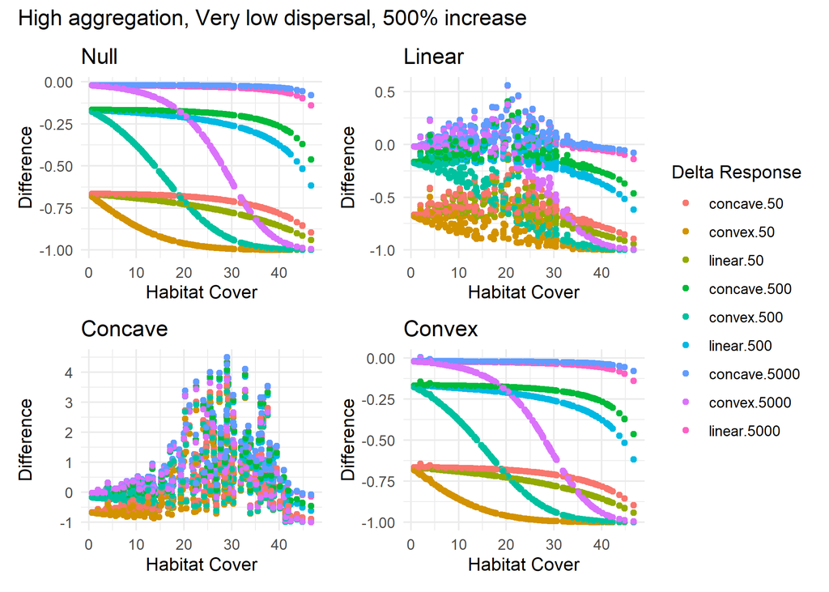

## 1.2 Unequal Colonisation and Extinction

The results when the colonisation and extinction constants are equal at a relative yield of 1, and when the colonisation constant is much greater than or much less than the extinction rate are largely similar. There are, however, some key differences.

### 1.2.1 Sparing and Sharing with low to very high levels of dispersal

The high levels of metapopulation capacity seen in the sparing responses, mean that differences in delta make little difference to whether a species can persist in a given landscape.

Even for the responses with two peaks, little variation is seen between extinction/ colonisation ratios as metapopulation capacity values remain very high.

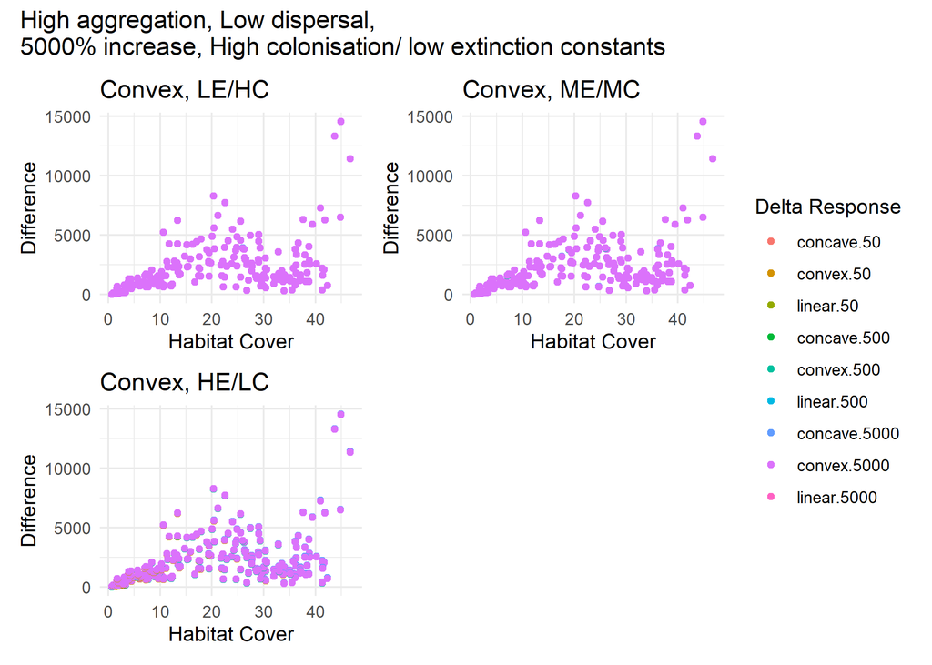

### 1.2.2 Sparing and Sharing with very low levels of dispersal

When, however, dispersal is very highly limited (mean dispersal distance of 10m at relative yield = 1), and metapopulation is very small, the extinction/ colonisation ratio becomes much more important. When the extinction/ colonisation ratio is lower at a relative yield of 1, metapopulation persistence becomes possible under more movement scenarios, a greater width of habitat amounts, and more colonisation constant responses. For example, in low aggregation landscapes, with very low species dispersal and a 500% increase in dispersal ability, species persistence is only possible under extreme linear and concave colonisation constant responses if the extinction/ colonisation ratio is high. When the extinction/ colonisation ratio is low at a relative yield of 1, however, species persistence is possible under all colonisation constant responses. This is pattern is quite intuitive, as a low extinction/ colonisation constant ratio (0.01/0.5) is almost the same as a 5000% increase in colonisation constant seen in the equal extinction/ colonisation constant scenarios. The increase in colonisation constant with reduced yield is multiplied on top of this baseline 5000%. This means the threshold for persistence is much more reduced and allows for species to persist in more landscapes.

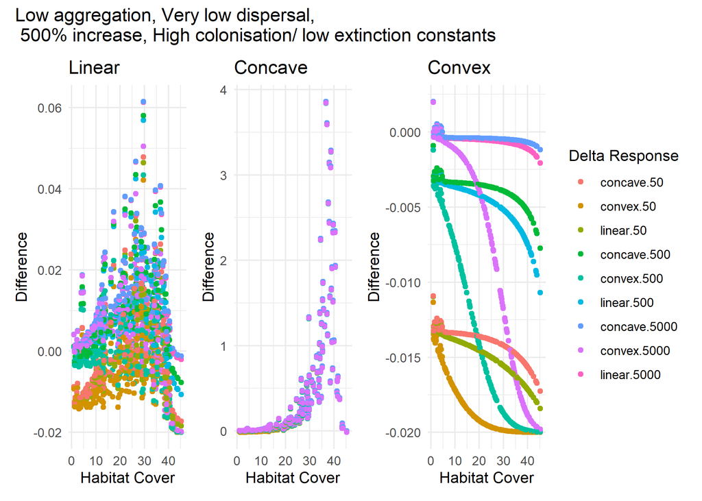

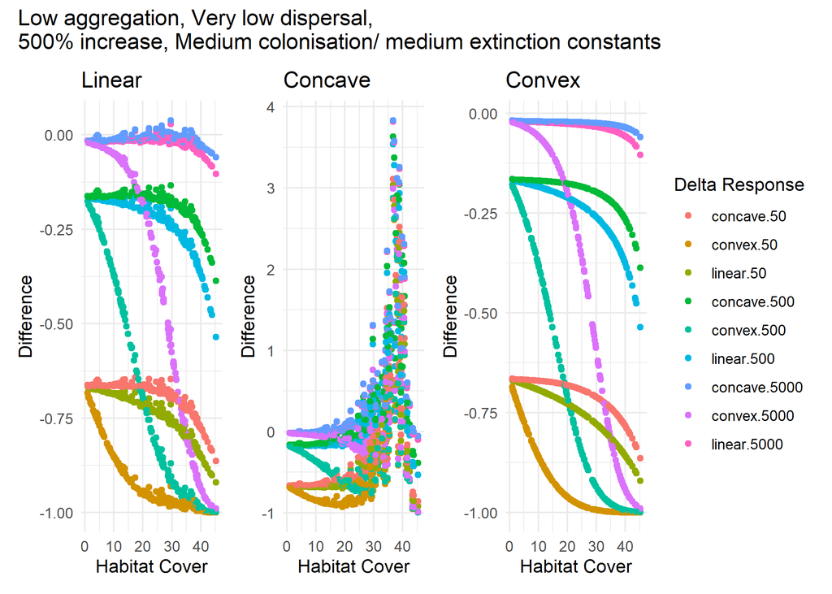

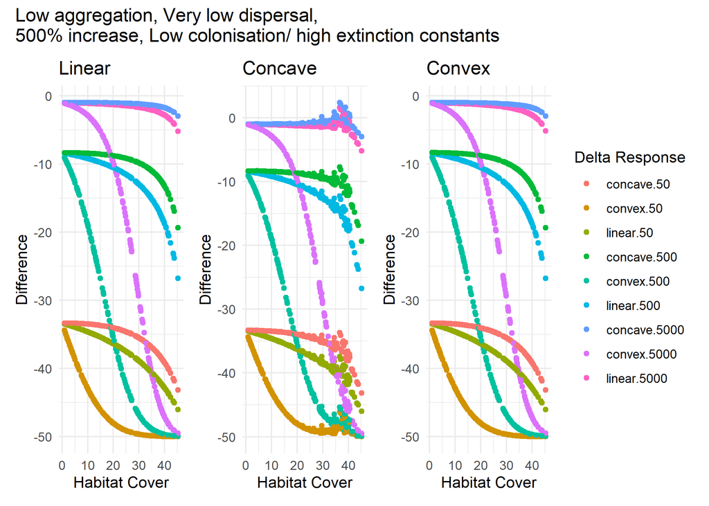

A very similar pattern can be seen when landscapes have a medium level of habitat aggregation.

[figure not shown]

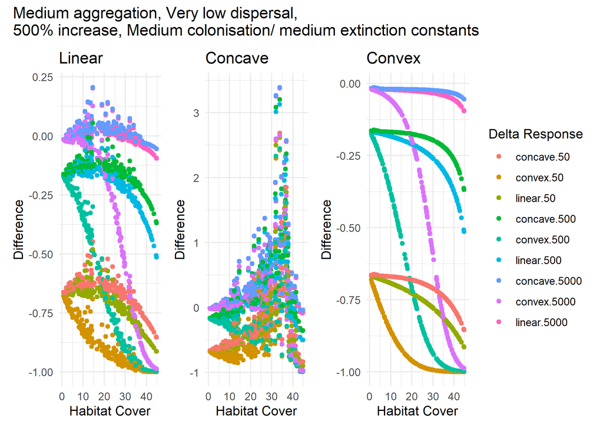

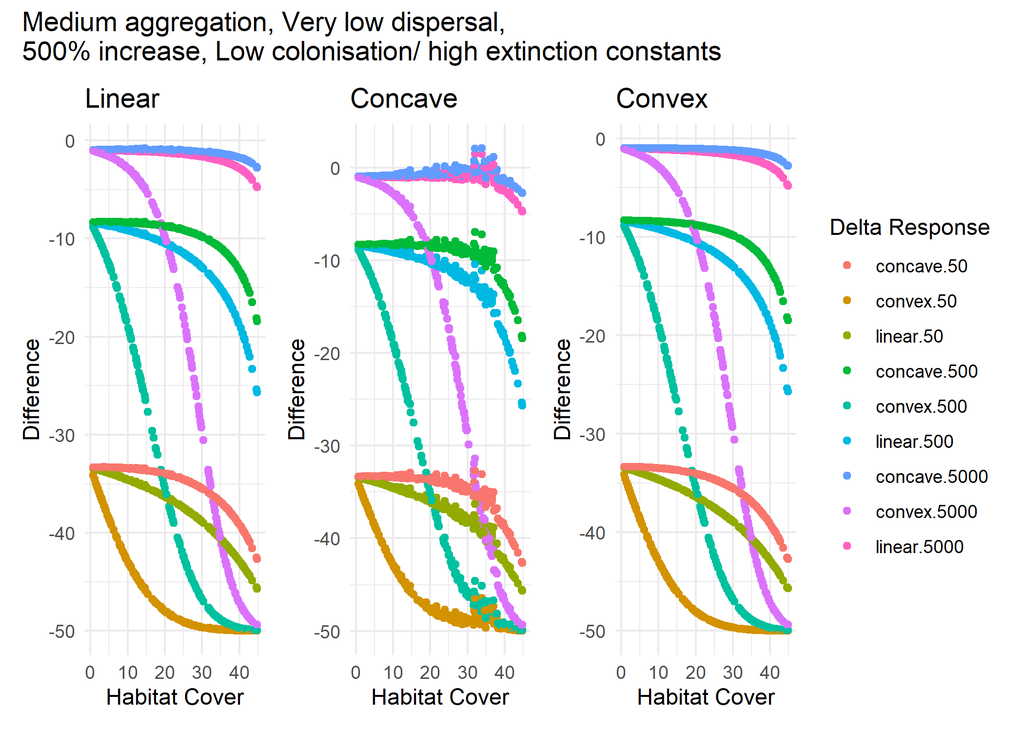

The pattern is further exaggerated in landscapes with high levels of habitat aggregation.

[figure not shown]

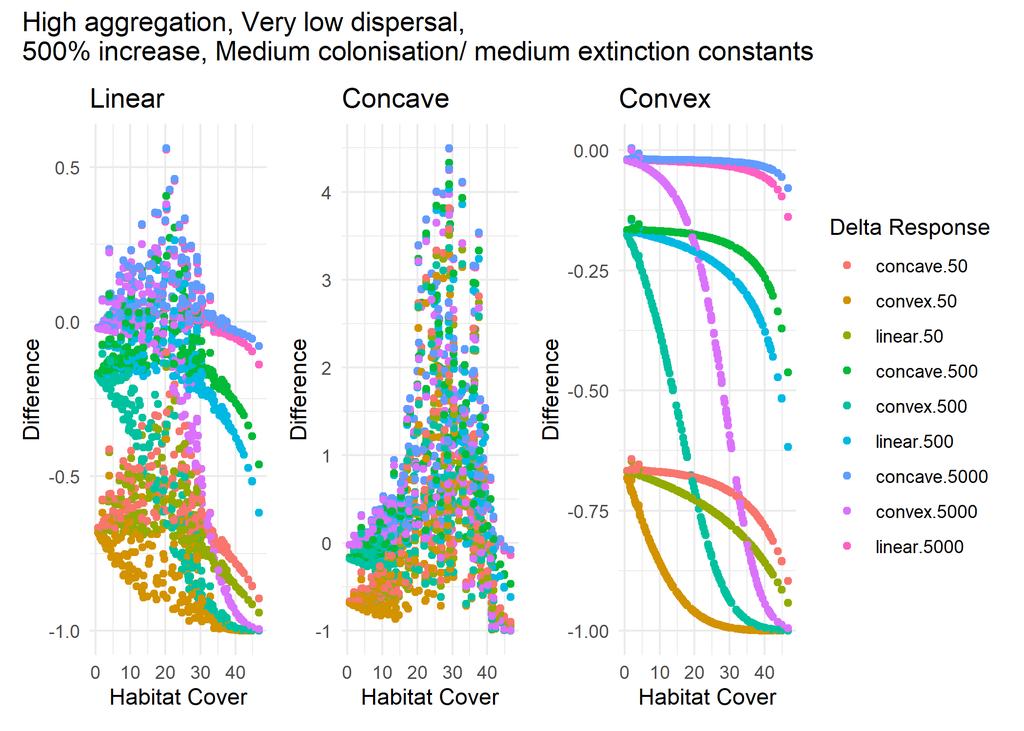

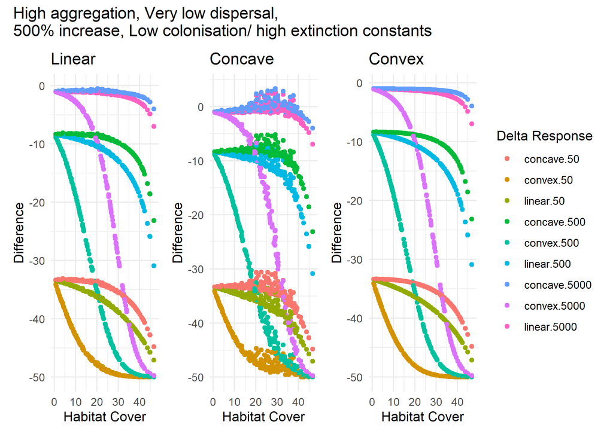